# Predicting Customer Churn in a Telecom Company

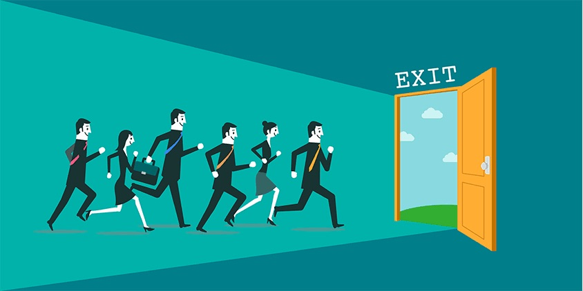

# Problem description:

A telecom company is facing a high customer churn rate and wants to reduce it. Customer churn refers to the process where a customer stops doing business with a company. In the telecom industry, customer churn is a major problem as acquiring new customers is more expensive than retaining existing customers. The company wants to use machine learning to predict which customers are likely to churn so that they can take proactive measures to retain them.

# About Dataset:

The dataset contains information on customer demographic, account information, services used, and whether or not they have churned. The target variable is a binary column indicating whether the customer has churned (1) or not (0).

```python
#importing all the necessary librarys
import pandas as pd
import numpy as np
import seaborn as sns
import matplotlib.pyplot as plt
```

```python
#loading train data and displaying all columns using set_options
df = pd.read_csv('train.csv')
pd.set_option("display.max_columns", 21)
df.head()
```

|  | customerID | gender | SeniorCitizen | Partner | Dependents | tenure | PhoneService | MultipleLines | InternetService | OnlineSecurity | OnlineBackup | DeviceProtection | TechSupport | StreamingTV | StreamingMovies | Contract | PaperlessBilling | PaymentMethod | MonthlyCharges | TotalCharges | Churn |
| --- | --- | --- | --- | --- | --- | --- | --- | --- | --- | --- | --- | --- | --- | --- | --- | --- | --- | --- | --- | --- | --- |
| 0 | 7590-VHVEG | Female | 0 | Yes | No | 1 | No | No phone service | DSL | No | Yes | No | No | No | No | Month-to-month | Yes | Electronic check | 29.85 | 29.85 | No |
| 1 | 5575-GNVDE | Male | 0 | No | No | 34 | Yes | No | DSL | Yes | No | Yes | No | No | No | One year | No | Mailed check | 56.95 | 1889.5 | No |
| 2 | 3668-QPYBK | Male | 0 | No | No | 2 | Yes | No | DSL | Yes | Yes | No | No | No | No | Month-to-month | Yes | Mailed check | 53.85 | 108.15 | Yes |
| 3 | 7795-CFOCW | Male | 0 | No | No | 45 | No | No phone service | DSL | Yes | No | Yes | Yes | No | No | One year | No | Bank transfer (automatic) | 42.30 | 1840.75 | No |
| 4 | 9237-HQITU | Female | 0 | No | No | 2 | Yes | No | Fiber optic | No | No | No | No | No | No | Month-to-month | Yes | Electronic check | 70.70 | 151.65 | Yes |

```python
#loading test data and displaying all columns using set_options
df1 = pd.read_csv('test.csv')
pd.set_option("display.max_columns", 21)
df1
```

|  | gender | SeniorCitizen | Partner | Dependents | tenure | PhoneService | MultipleLines | InternetService | OnlineSecurity | OnlineBackup | DeviceProtection | TechSupport | StreamingTV | StreamingMovies | Contract | PaperlessBilling | PaymentMethod | MonthlyCharges | TotalCharges |
| --- | --- | --- | --- | --- | --- | --- | --- | --- | --- | --- | --- | --- | --- | --- | --- | --- | --- | --- | --- |
| 0 | Male | 0 | No | No | 25 | Yes | No | Fiber optic | Yes | no | yes | Yes | Yes | Yes | Month-to-month | Yes | Electronic check | 106.00 | 2787.00 |
| 1 | Female | 0 | Yes | No | 1 | No | No phone service | DSL | No | Yes | No | No | No | No | Month-to-month | Yes | Electronic check | 30.00 | 30.00 |
| 2 | Female | 0 | Yes | No | 1 | No | No phone service | DSL | No | Yes | No | No | No | No | Month-to-month | Yes | Electronic check | 29.85 | 29.85 |
| 3 | Female | 0 | Yes | No | 1 | No | No phone service | DSL | No | Yes | No | No | No | No | Month-to-month | Yes | Electronic check | 29.85 | 29.85 |
| 4 | Female | 0 | Yes | No | 1 | No | No phone service | DSL | No | Yes | No | No | No | No | Month-to-month | Yes | Electronic check | 29.85 | 29.85 |
| 5 | Male | 0 | No | No | 34 | Yes | No | DSL | Yes | No | Yes | No | No | No | One year | No | Mailed check | 56.95 | 1889.50 |
| 6 | Male | 0 | No | No | 2 | Yes | No | DSL | Yes | Yes | No | No | No | No | Month-to-month | Yes | Mailed check | 53.85 | 108.15 |
| 7 | Male | 0 | No | No | 45 | No | No phone service | DSL | Yes | No | Yes | Yes | No | No | One year | No | Bank transfer (automatic) | 42.30 | 1840.75 |
| 8 | Female | 0 | No | No | 2 | Yes | No | Fiber optic | No | No | No | No | No | No | Month-to-month | Yes | Electronic check | 70.70 | 151.65 |
| 9 | Female | 0 | No | No | 8 | Yes | Yes | Fiber optic | No | No | Yes | No | Yes | Yes | Month-to-month | Yes | Electronic check | 99.65 | 820.50 |
| 10 | Male | 0 | No | Yes | 22 | Yes | Yes | Fiber optic | No | Yes | No | No | Yes | No | Month-to-month | Yes | Credit card (automatic) | 89.10 | 1949.40 |
| 11 | Female | 0 | No | No | 10 | No | No phone service | DSL | Yes | No | No | No | No | No | Month-to-month | No | Mailed check | 29.75 | 301.90 |
| 12 | Female | 0 | Yes | No | 28 | Yes | Yes | Fiber optic | No | No | Yes | Yes | Yes | Yes | Month-to-month | Yes | Electronic check | 104.80 | 3046.05 |
| 13 | Male | 0 | No | Yes | 62 | Yes | No | DSL | Yes | Yes | No | No | No | No | One year | No | Bank transfer (automatic) | 56.15 | 3487.95 |
| 14 | Male | 0 | Yes | Yes | 13 | Yes | No | DSL | Yes | No | No | No | No | No | Month-to-month | Yes | Mailed check | 49.95 | 587.45 |
| 15 | Male | 0 | No | No | 16 | Yes | No | No | No internet service | No internet service | No internet service | No internet service | No internet service | No internet service | Two year | No | Credit card (automatic) | 18.95 | 326.80 |
| 16 | Male | 0 | Yes | No | 58 | Yes | Yes | Fiber optic | No | No | Yes | No | Yes | Yes | One year | No | Credit card (automatic) | 100.35 | 5681.10 |
| 17 | Male | 0 | No | No | 49 | Yes | Yes | Fiber optic | No | Yes | Yes | No | Yes | Yes | Month-to-month | Yes | Bank transfer (automatic) | 103.70 | 5036.30 |
| 18 | Male | 0 | No | No | 25 | Yes | No | Fiber optic | Yes | No | Yes | Yes | Yes | Yes | Month-to-month | Yes | Electronic check | 105.50 | 2686.05 |
| 19 | Male | 0 | No | No | 25 | Yes | No | Fiber optic | Yes | no | yes | Yes | Yes | Yes | Month-to-month | Yes | Electronic check | 106.00 | 2787.00 |

```python
#it will return a new DataFrame containing summary statistics for each numerical column in the original DataFrame.
#The summary statistics include count, mean, standard deviation, minimum value, 25th percentile, median, 75th percentile, and maximum value.
df.describe()
```

|  | SeniorCitizen | tenure | MonthlyCharges |
| --- | --- | --- | --- |
| count | 7043.000000 | 7043.000000 | 7043.000000 |
| mean | 0.162147 | 32.371149 | 64.761692 |
| std | 0.368612 | 24.559481 | 30.090047 |
| min | 0.000000 | 0.000000 | 18.250000 |
| 25% | 0.000000 | 9.000000 | 35.500000 |
| 50% | 0.000000 | 29.000000 | 70.350000 |
| 75% | 0.000000 | 55.000000 | 89.850000 |
| max | 1.000000 | 72.000000 | 118.750000 |

```python
#returns Datatype of the particular attribute
df.dtypes
```

```
customerID           object
gender               object
SeniorCitizen         int64
Partner              object
Dependents           object
tenure                int64
PhoneService         object
MultipleLines        object
InternetService      object
OnlineSecurity       object
OnlineBackup         object
DeviceProtection     object
TechSupport          object
StreamingTV          object
StreamingMovies      object
Contract             object
PaperlessBilling     object
PaymentMethod        object
MonthlyCharges      float64
TotalCharges         object
Churn                object
dtype: object
```

```python
#drop() is used to drop unwanted attributes
df=df.drop('customerID',axis=1)
```

```python
#select_dtypes() returns the required dtypes attributes
obj=df.select_dtypes(include='object')
obj.columns
```

```
Index(['gender', 'Partner', 'Dependents', 'PhoneService', 'MultipleLines',
       'InternetService', 'OnlineSecurity', 'OnlineBackup', 'DeviceProtection',
       'TechSupport', 'StreamingTV', 'StreamingMovies', 'Contract',
       'PaperlessBilling', 'PaymentMethod', 'TotalCharges', 'Churn'],
      dtype='object')
```

```python
#from pandas to_numeric() converts object type data to numeric type
df['TotalCharges'] = pd.to_numeric(df['TotalCharges'], errors='coerce')
```

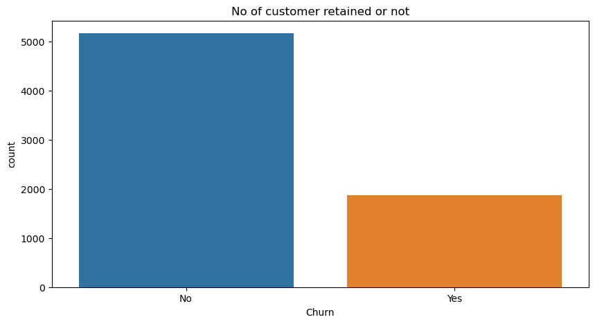

```python
#checking count of customer retained or not
plt.figure(figsize=(10,5))
sns.countplot(x= df["Churn"])
plt.title("No of customer retained or not")
plt.show()
```

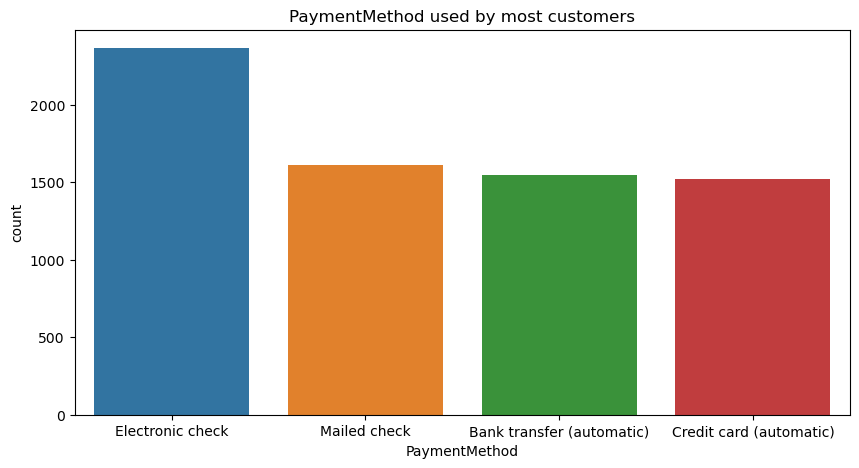

```python
#ploting which PaymentMethod which is used by most customers
plt.figure(figsize=(10,5))
sns.countplot(x= df["PaymentMethod"])
plt.title("PaymentMethod used by most customers")
plt.show()
```

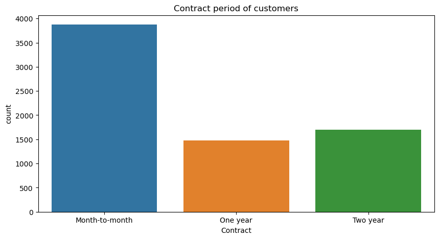

```python
#ploting Contract period of customers
plt.figure(figsize=(10,5))
sns.countplot(x= df["Contract"])
plt.title("Contract period of customers")
plt.show()
```

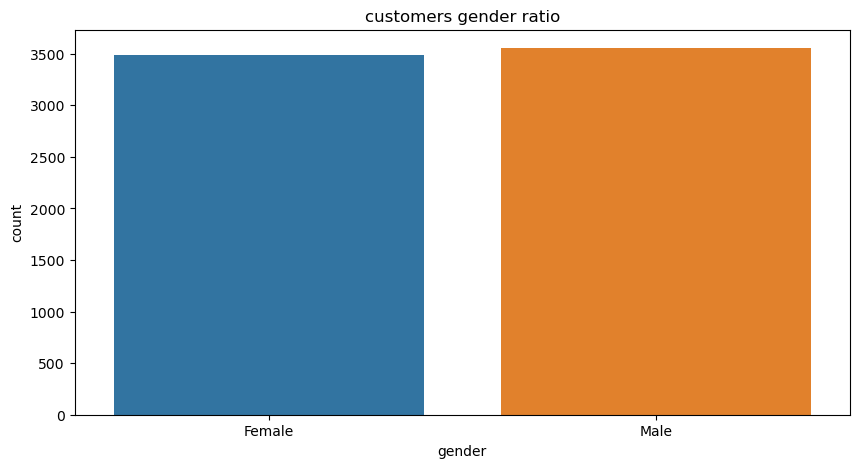

```python
#ploting customers gender ratio
plt.figure(figsize=(10,5))
sns.countplot(x= df["gender"])
plt.title('customers gender ratio')
plt.show()
```

```python
#user defined function for checking total count and percentage of missing values
def missing_check(df):
    total = df.isnull().sum().sort_values(ascending=False)   # total number of null values
    percent = (df.isnull().sum()/df.isnull().count()).sort_values(ascending=False)  # percentage of values that are null
    missing_data = pd.concat([total, percent], axis=1, keys=['Total', 'Percent'])  # putting the above two together
    return missing_data # return the dataframe
```

```python
#using missing_check() function to check count and percentage of missing values
missing_check(df)
```

|  | Total | Percent |
| --- | --- | --- |
| TotalCharges | 11 | 0.001562 |
| gender | 0 | 0.000000 |
| SeniorCitizen | 0 | 0.000000 |
| MonthlyCharges | 0 | 0.000000 |
| PaymentMethod | 0 | 0.000000 |
| PaperlessBilling | 0 | 0.000000 |
| Contract | 0 | 0.000000 |
| StreamingMovies | 0 | 0.000000 |
| StreamingTV | 0 | 0.000000 |
| TechSupport | 0 | 0.000000 |
| DeviceProtection | 0 | 0.000000 |
| OnlineBackup | 0 | 0.000000 |
| OnlineSecurity | 0 | 0.000000 |
| InternetService | 0 | 0.000000 |
| MultipleLines | 0 | 0.000000 |
| PhoneService | 0 | 0.000000 |
| tenure | 0 | 0.000000 |
| Dependents | 0 | 0.000000 |
| Partner | 0 | 0.000000 |
| Churn | 0 | 0.000000 |

```python
#checking unique values in attributes for train data
for i in df.columns:
    print(i,df[i].unique())
```

```
gender ['Female' 'Male']
SeniorCitizen [0 1]
Partner ['Yes' 'No']
Dependents ['No' 'Yes']
tenure [ 1 34  2 45  8 22 10 28 62 13 16 58 49 25 69 52 71 21 12 30 47 72 17 27
  5 46 11 70 63 43 15 60 18 66  9  3 31 50 64 56  7 42 35 48 29 65 38 68
 32 55 37 36 41  6  4 33 67 23 57 61 14 20 53 40 59 24 44 19 54 51 26  0
 39]
PhoneService ['No' 'Yes']
MultipleLines ['No phone service' 'No' 'Yes']
InternetService ['DSL' 'Fiber optic' 'No']
OnlineSecurity ['No' 'Yes' 'No internet service']
OnlineBackup ['Yes' 'No' 'No internet service']
DeviceProtection ['No' 'Yes' 'No internet service']
TechSupport ['No' 'Yes' 'No internet service']
StreamingTV ['No' 'Yes' 'No internet service']
StreamingMovies ['No' 'Yes' 'No internet service']
Contract ['Month-to-month' 'One year' 'Two year']
PaperlessBilling ['Yes' 'No']
PaymentMethod ['Electronic check' 'Mailed check' 'Bank transfer (automatic)'
 'Credit card (automatic)']
MonthlyCharges [29.85 56.95 53.85 ... 63.1  44.2  78.7 ]
TotalCharges [  29.85 1889.5   108.15 ...  346.45  306.6  6844.5 ]
Churn ['No' 'Yes']
```

```python
#MultipleLines,OnlineSecurity,OnlineBackup,DeviceProtection etc some columns has "No phone service" which can be replaced
#by No


df['MultipleLines']=df['MultipleLines'].replace('No phone service','No')
df['OnlineSecurity']=df['OnlineSecurity'].replace('No internet service','No')

df['OnlineBackup']=df['OnlineBackup'].replace('No internet service','No')
df['DeviceProtection']=df['DeviceProtection'].replace('No internet service','No')

df['TechSupport']=df['TechSupport'].replace('No internet service','No')
df['StreamingTV']=df['StreamingTV'].replace('No internet service','No')

df['StreamingMovies']=df['StreamingMovies'].replace('No internet service','No')
```

```python
#checking unique values in attributes after replacing
for i in df.columns:
    print(i,df[i].unique())
```

```
gender ['Female' 'Male']
SeniorCitizen [0 1]
Partner ['Yes' 'No']
Dependents ['No' 'Yes']
tenure [ 1 34  2 45  8 22 10 28 62 13 16 58 49 25 69 52 71 21 12 30 47 72 17 27
  5 46 11 70 63 43 15 60 18 66  9  3 31 50 64 56  7 42 35 48 29 65 38 68
 32 55 37 36 41  6  4 33 67 23 57 61 14 20 53 40 59 24 44 19 54 51 26  0
 39]
PhoneService ['No' 'Yes']
MultipleLines ['No' 'Yes']
InternetService ['DSL' 'Fiber optic' 'No']
OnlineSecurity ['No' 'Yes']
OnlineBackup ['Yes' 'No']
DeviceProtection ['No' 'Yes']
TechSupport ['No' 'Yes']
StreamingTV ['No' 'Yes']
StreamingMovies ['No' 'Yes']
Contract ['Month-to-month' 'One year' 'Two year']
PaperlessBilling ['Yes' 'No']
PaymentMethod ['Electronic check' 'Mailed check' 'Bank transfer (automatic)'
 'Credit card (automatic)']
MonthlyCharges [29.85 56.95 53.85 ... 63.1  44.2  78.7 ]
TotalCharges [  29.85 1889.5   108.15 ...  346.45  306.6  6844.5 ]
Churn ['No' 'Yes']
```

```python
#checking unique values in attributes for test data
for i in df1.columns:
    print(i,df1[i].unique())
```

```
gender ['Male' 'Female']
SeniorCitizen [0]
Partner ['No' 'Yes']
Dependents ['No' 'Yes']
tenure [25  1 34  2 45  8 22 10 28 62 13 16 58 49]
PhoneService ['Yes' 'No']
MultipleLines ['No' 'No phone service' 'Yes']
InternetService ['Fiber optic' 'DSL' 'No']
OnlineSecurity ['Yes' 'No' 'No internet service']
OnlineBackup ['no' 'Yes' 'No' 'No internet service']
DeviceProtection ['yes' 'No' 'Yes' 'No internet service']
TechSupport ['Yes' 'No' 'No internet service']
StreamingTV ['Yes' 'No' 'No internet service']
StreamingMovies ['Yes' 'No' 'No internet service']
Contract ['Month-to-month' 'One year' 'Two year']
PaperlessBilling ['Yes' 'No']
PaymentMethod ['Electronic check' 'Mailed check' 'Bank transfer (automatic)'
 'Credit card (automatic)']
MonthlyCharges [106.    30.    29.85  56.95  53.85  42.3   70.7   99.65  89.1   29.75
 104.8   56.15  49.95  18.95 100.35 103.7  105.5 ]
TotalCharges [2787.     30.     29.85 1889.5   108.15 1840.75  151.65  820.5  1949.4
  301.9  3046.05 3487.95  587.45  326.8  5681.1  5036.3  2686.05]
```

```python
#i have encounterd small letter no and yes in some records this might take another value while doing laber encoing
#so i have replaced with capital Yes and No


df1['MultipleLines']=df1['MultipleLines'].replace('No phone service','No')
df1['OnlineSecurity']=df1['OnlineSecurity'].replace('No internet service','No')

df1['OnlineBackup']=df1['OnlineBackup'].replace('No internet service','No')
df1['DeviceProtection']=df1['DeviceProtection'].replace('No internet service','No')

df1['TechSupport']=df1['TechSupport'].replace('No internet service','No')
df1['StreamingTV']=df1['StreamingTV'].replace('No internet service','No')

df1['StreamingMovies']=df1['StreamingMovies'].replace('No internet service','No')

df1['OnlineBackup']=df1['OnlineBackup'].replace('no','No')
df1['DeviceProtection']=df1['DeviceProtection'].replace('yes','Yes')
```

```python
#checking unique values in attributes after replacing in test data
for i in df1.columns:
    print(i,df1[i].unique())
```

```
gender ['Male' 'Female']
SeniorCitizen [0]
Partner ['No' 'Yes']
Dependents ['No' 'Yes']
tenure [25  1 34  2 45  8 22 10 28 62 13 16 58 49]
PhoneService ['Yes' 'No']
MultipleLines ['No' 'Yes']
InternetService ['Fiber optic' 'DSL' 'No']
OnlineSecurity ['Yes' 'No']
OnlineBackup ['No' 'Yes']
DeviceProtection ['Yes' 'No']
TechSupport ['Yes' 'No']
StreamingTV ['Yes' 'No']
StreamingMovies ['Yes' 'No']
Contract ['Month-to-month' 'One year' 'Two year']
PaperlessBilling ['Yes' 'No']
PaymentMethod ['Electronic check' 'Mailed check' 'Bank transfer (automatic)'
 'Credit card (automatic)']
MonthlyCharges [106.    30.    29.85  56.95  53.85  42.3   70.7   99.65  89.1   29.75
 104.8   56.15  49.95  18.95 100.35 103.7  105.5 ]
TotalCharges [2787.     30.     29.85 1889.5   108.15 1840.75  151.65  820.5  1949.4
  301.9  3046.05 3487.95  587.45  326.8  5681.1  5036.3  2686.05]
```

```python
#checking datatypes
df.dtypes
```

```
gender               object
SeniorCitizen         int64
Partner              object
Dependents           object
tenure                int64
PhoneService         object
MultipleLines        object
InternetService      object
OnlineSecurity       object
OnlineBackup         object
DeviceProtection     object
TechSupport          object
StreamingTV          object
StreamingMovies      object
Contract             object
PaperlessBilling     object
PaymentMethod        object
MonthlyCharges      float64
TotalCharges        float64
Churn                object
dtype: object
```

```python
#filling na value with mean()
df['TotalCharges']=df['TotalCharges'].fillna(df['TotalCharges'].mean())
```

```python
missing_check(df)
```

|  | Total | Percent |
| --- | --- | --- |
| gender | 0 | 0.0 |
| SeniorCitizen | 0 | 0.0 |
| TotalCharges | 0 | 0.0 |
| MonthlyCharges | 0 | 0.0 |
| PaymentMethod | 0 | 0.0 |
| PaperlessBilling | 0 | 0.0 |
| Contract | 0 | 0.0 |
| StreamingMovies | 0 | 0.0 |
| StreamingTV | 0 | 0.0 |
| TechSupport | 0 | 0.0 |
| DeviceProtection | 0 | 0.0 |
| OnlineBackup | 0 | 0.0 |
| OnlineSecurity | 0 | 0.0 |
| InternetService | 0 | 0.0 |
| MultipleLines | 0 | 0.0 |
| PhoneService | 0 | 0.0 |
| tenure | 0 | 0.0 |
| Dependents | 0 | 0.0 |
| Partner | 0 | 0.0 |
| Churn | 0 | 0.0 |

```python
df
```

|  | gender | SeniorCitizen | Partner | Dependents | tenure | PhoneService | MultipleLines | InternetService | OnlineSecurity | OnlineBackup | DeviceProtection | TechSupport | StreamingTV | StreamingMovies | Contract | PaperlessBilling | PaymentMethod | MonthlyCharges | TotalCharges | Churn |
| --- | --- | --- | --- | --- | --- | --- | --- | --- | --- | --- | --- | --- | --- | --- | --- | --- | --- | --- | --- | --- |
| 0 | Female | 0 | Yes | No | 1 | No | No | DSL | No | Yes | No | No | No | No | Month-to-month | Yes | Electronic check | 29.85 | 29.85 | No |
| 1 | Male | 0 | No | No | 34 | Yes | No | DSL | Yes | No | Yes | No | No | No | One year | No | Mailed check | 56.95 | 1889.50 | No |
| 2 | Male | 0 | No | No | 2 | Yes | No | DSL | Yes | Yes | No | No | No | No | Month-to-month | Yes | Mailed check | 53.85 | 108.15 | Yes |
| 3 | Male | 0 | No | No | 45 | No | No | DSL | Yes | No | Yes | Yes | No | No | One year | No | Bank transfer (automatic) | 42.30 | 1840.75 | No |
| 4 | Female | 0 | No | No | 2 | Yes | No | Fiber optic | No | No | No | No | No | No | Month-to-month | Yes | Electronic check | 70.70 | 151.65 | Yes |
| ... | ... | ... | ... | ... | ... | ... | ... | ... | ... | ... | ... | ... | ... | ... | ... | ... | ... | ... | ... | ... |
| 7038 | Male | 0 | Yes | Yes | 24 | Yes | Yes | DSL | Yes | No | Yes | Yes | Yes | Yes | One year | Yes | Mailed check | 84.80 | 1990.50 | No |
| 7039 | Female | 0 | Yes | Yes | 72 | Yes | Yes | Fiber optic | No | Yes | Yes | No | Yes | Yes | One year | Yes | Credit card (automatic) | 103.20 | 7362.90 | No |
| 7040 | Female | 0 | Yes | Yes | 11 | No | No | DSL | Yes | No | No | No | No | No | Month-to-month | Yes | Electronic check | 29.60 | 346.45 | No |
| 7041 | Male | 1 | Yes | No | 4 | Yes | Yes | Fiber optic | No | No | No | No | No | No | Month-to-month | Yes | Mailed check | 74.40 | 306.60 | Yes |
| 7042 | Male | 0 | No | No | 66 | Yes | No | Fiber optic | Yes | No | Yes | Yes | Yes | Yes | Two year | Yes | Bank transfer (automatic) | 105.65 | 6844.50 | No |

7043 rows × 20 columns

```python
df.corr()
```

|  | SeniorCitizen | tenure | MonthlyCharges | TotalCharges |
| --- | --- | --- | --- | --- |
| SeniorCitizen | 1.000000 | 0.016567 | 0.220173 | 0.102395 |
| tenure | 0.016567 | 1.000000 | 0.247900 | 0.824757 |
| MonthlyCharges | 0.220173 | 0.247900 | 1.000000 | 0.650468 |
| TotalCharges | 0.102395 | 0.824757 | 0.650468 | 1.000000 |

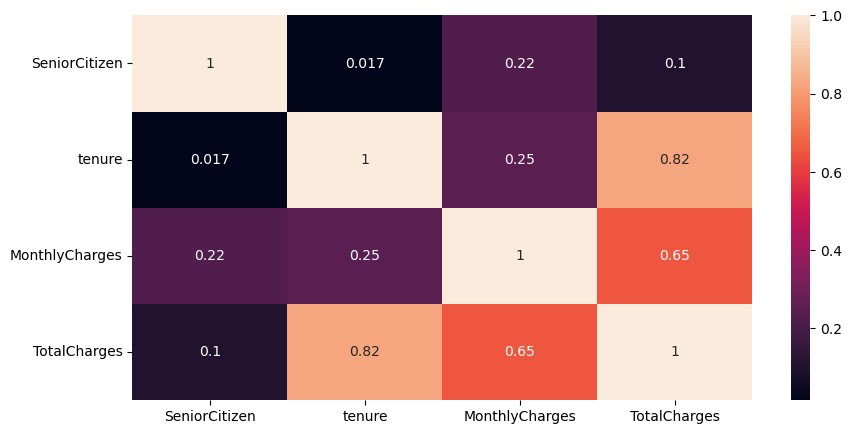

```python
plt.figure(figsize=(10,5))

# CORRELATION
sns.heatmap(df.corr(),annot=True)
plt.show()
```

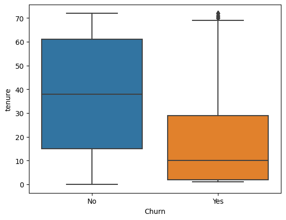

```python
#checking outliers
sns.boxplot(x=df["Churn"], y=df["tenure"])
plt.show()
```

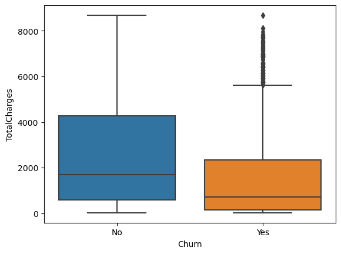

```python
#checking outliers
sns.boxplot(x=df["Churn"], y=df["TotalCharges"])
plt.show()
```

```python
df.columns
```

```
Index(['gender', 'SeniorCitizen', 'Partner', 'Dependents', 'tenure',
       'PhoneService', 'MultipleLines', 'InternetService', 'OnlineSecurity',
       'OnlineBackup', 'DeviceProtection', 'TechSupport', 'StreamingTV',
       'StreamingMovies', 'Contract', 'PaperlessBilling', 'PaymentMethod',
       'MonthlyCharges', 'TotalCharges', 'Churn'],
      dtype='object')
```

```python
# Transform object data using the label encoder
from sklearn.preprocessing import LabelEncoder

def encoding(df):
    label_encoder = LabelEncoder()
    object_columns = [col for col in df.columns if df[col].dtype == 'object']
    for col in object_columns:
        df[col] = label_encoder.fit_transform(df[col])
    return df
```

```python
df=encoding(df)
```

```python
df
```

|  | gender | SeniorCitizen | Partner | Dependents | tenure | PhoneService | MultipleLines | InternetService | OnlineSecurity | OnlineBackup | DeviceProtection | TechSupport | StreamingTV | StreamingMovies | Contract | PaperlessBilling | PaymentMethod | MonthlyCharges | TotalCharges | Churn |
| --- | --- | --- | --- | --- | --- | --- | --- | --- | --- | --- | --- | --- | --- | --- | --- | --- | --- | --- | --- | --- |
| 0 | 0 | 0 | 1 | 0 | 1 | 0 | 0 | 0 | 0 | 1 | 0 | 0 | 0 | 0 | 0 | 1 | 2 | 29.85 | 29.85 | 0 |
| 1 | 1 | 0 | 0 | 0 | 34 | 1 | 0 | 0 | 1 | 0 | 1 | 0 | 0 | 0 | 1 | 0 | 3 | 56.95 | 1889.50 | 0 |
| 2 | 1 | 0 | 0 | 0 | 2 | 1 | 0 | 0 | 1 | 1 | 0 | 0 | 0 | 0 | 0 | 1 | 3 | 53.85 | 108.15 | 1 |
| 3 | 1 | 0 | 0 | 0 | 45 | 0 | 0 | 0 | 1 | 0 | 1 | 1 | 0 | 0 | 1 | 0 | 0 | 42.30 | 1840.75 | 0 |
| 4 | 0 | 0 | 0 | 0 | 2 | 1 | 0 | 1 | 0 | 0 | 0 | 0 | 0 | 0 | 0 | 1 | 2 | 70.70 | 151.65 | 1 |
| ... | ... | ... | ... | ... | ... | ... | ... | ... | ... | ... | ... | ... | ... | ... | ... | ... | ... | ... | ... | ... |
| 7038 | 1 | 0 | 1 | 1 | 24 | 1 | 1 | 0 | 1 | 0 | 1 | 1 | 1 | 1 | 1 | 1 | 3 | 84.80 | 1990.50 | 0 |
| 7039 | 0 | 0 | 1 | 1 | 72 | 1 | 1 | 1 | 0 | 1 | 1 | 0 | 1 | 1 | 1 | 1 | 1 | 103.20 | 7362.90 | 0 |
| 7040 | 0 | 0 | 1 | 1 | 11 | 0 | 0 | 0 | 1 | 0 | 0 | 0 | 0 | 0 | 0 | 1 | 2 | 29.60 | 346.45 | 0 |
| 7041 | 1 | 1 | 1 | 0 | 4 | 1 | 1 | 1 | 0 | 0 | 0 | 0 | 0 | 0 | 0 | 1 | 3 | 74.40 | 306.60 | 1 |
| 7042 | 1 | 0 | 0 | 0 | 66 | 1 | 0 | 1 | 1 | 0 | 1 | 1 | 1 | 1 | 2 | 1 | 0 | 105.65 | 6844.50 | 0 |

7043 rows × 20 columns

```python
#spliting independent and dependent variable
y=df['Churn'].values
X=df.drop('Churn',axis=1)
```

```python
y
```

```
array([0, 0, 1, ..., 0, 1, 0])
```

```python
X
```

|  | gender | SeniorCitizen | Partner | Dependents | tenure | PhoneService | MultipleLines | InternetService | OnlineSecurity | OnlineBackup | DeviceProtection | TechSupport | StreamingTV | StreamingMovies | Contract | PaperlessBilling | PaymentMethod | MonthlyCharges | TotalCharges |
| --- | --- | --- | --- | --- | --- | --- | --- | --- | --- | --- | --- | --- | --- | --- | --- | --- | --- | --- | --- |
| 0 | 0 | 0 | 1 | 0 | 1 | 0 | 0 | 0 | 0 | 1 | 0 | 0 | 0 | 0 | 0 | 1 | 2 | 29.85 | 29.85 |
| 1 | 1 | 0 | 0 | 0 | 34 | 1 | 0 | 0 | 1 | 0 | 1 | 0 | 0 | 0 | 1 | 0 | 3 | 56.95 | 1889.50 |
| 2 | 1 | 0 | 0 | 0 | 2 | 1 | 0 | 0 | 1 | 1 | 0 | 0 | 0 | 0 | 0 | 1 | 3 | 53.85 | 108.15 |
| 3 | 1 | 0 | 0 | 0 | 45 | 0 | 0 | 0 | 1 | 0 | 1 | 1 | 0 | 0 | 1 | 0 | 0 | 42.30 | 1840.75 |
| 4 | 0 | 0 | 0 | 0 | 2 | 1 | 0 | 1 | 0 | 0 | 0 | 0 | 0 | 0 | 0 | 1 | 2 | 70.70 | 151.65 |
| ... | ... | ... | ... | ... | ... | ... | ... | ... | ... | ... | ... | ... | ... | ... | ... | ... | ... | ... | ... |
| 7038 | 1 | 0 | 1 | 1 | 24 | 1 | 1 | 0 | 1 | 0 | 1 | 1 | 1 | 1 | 1 | 1 | 3 | 84.80 | 1990.50 |
| 7039 | 0 | 0 | 1 | 1 | 72 | 1 | 1 | 1 | 0 | 1 | 1 | 0 | 1 | 1 | 1 | 1 | 1 | 103.20 | 7362.90 |
| 7040 | 0 | 0 | 1 | 1 | 11 | 0 | 0 | 0 | 1 | 0 | 0 | 0 | 0 | 0 | 0 | 1 | 2 | 29.60 | 346.45 |
| 7041 | 1 | 1 | 1 | 0 | 4 | 1 | 1 | 1 | 0 | 0 | 0 | 0 | 0 | 0 | 0 | 1 | 3 | 74.40 | 306.60 |
| 7042 | 1 | 0 | 0 | 0 | 66 | 1 | 0 | 1 | 1 | 0 | 1 | 1 | 1 | 1 | 2 | 1 | 0 | 105.65 | 6844.50 |

7043 rows × 19 columns

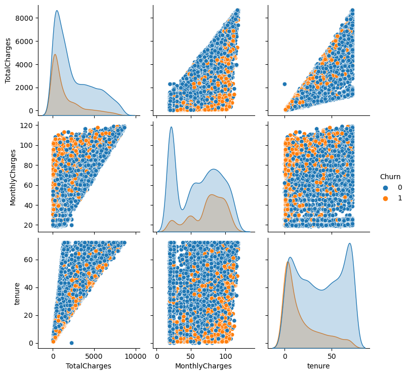

```python
sns.pairplot(df[['TotalCharges', 'MonthlyCharges', 'tenure', 'Churn']], hue='Churn')
```

```python
from imblearn.over_sampling import SMOTE
```

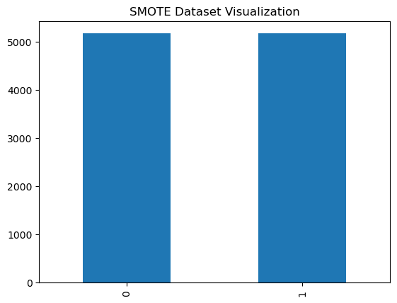

```python
# SMOTE
X_SMOTE, y_SMOTE = SMOTE().fit_resample(X, y)
#SMOTE plot
pd.Series(y_SMOTE).value_counts().plot(kind="bar")
plt.title("SMOTE Dataset Visualization")
plt.show()
```

# Test Preprocessing

```python
#printing test dataframe
df1
```

|  | gender | SeniorCitizen | Partner | Dependents | tenure | PhoneService | MultipleLines | InternetService | OnlineSecurity | OnlineBackup | DeviceProtection | TechSupport | StreamingTV | StreamingMovies | Contract | PaperlessBilling | PaymentMethod | MonthlyCharges | TotalCharges |
| --- | --- | --- | --- | --- | --- | --- | --- | --- | --- | --- | --- | --- | --- | --- | --- | --- | --- | --- | --- |
| 0 | Male | 0 | No | No | 25 | Yes | No | Fiber optic | Yes | No | Yes | Yes | Yes | Yes | Month-to-month | Yes | Electronic check | 106.00 | 2787.00 |
| 1 | Female | 0 | Yes | No | 1 | No | No | DSL | No | Yes | No | No | No | No | Month-to-month | Yes | Electronic check | 30.00 | 30.00 |
| 2 | Female | 0 | Yes | No | 1 | No | No | DSL | No | Yes | No | No | No | No | Month-to-month | Yes | Electronic check | 29.85 | 29.85 |
| 3 | Female | 0 | Yes | No | 1 | No | No | DSL | No | Yes | No | No | No | No | Month-to-month | Yes | Electronic check | 29.85 | 29.85 |
| 4 | Female | 0 | Yes | No | 1 | No | No | DSL | No | Yes | No | No | No | No | Month-to-month | Yes | Electronic check | 29.85 | 29.85 |
| 5 | Male | 0 | No | No | 34 | Yes | No | DSL | Yes | No | Yes | No | No | No | One year | No | Mailed check | 56.95 | 1889.50 |
| 6 | Male | 0 | No | No | 2 | Yes | No | DSL | Yes | Yes | No | No | No | No | Month-to-month | Yes | Mailed check | 53.85 | 108.15 |
| 7 | Male | 0 | No | No | 45 | No | No | DSL | Yes | No | Yes | Yes | No | No | One year | No | Bank transfer (automatic) | 42.30 | 1840.75 |
| 8 | Female | 0 | No | No | 2 | Yes | No | Fiber optic | No | No | No | No | No | No | Month-to-month | Yes | Electronic check | 70.70 | 151.65 |
| 9 | Female | 0 | No | No | 8 | Yes | Yes | Fiber optic | No | No | Yes | No | Yes | Yes | Month-to-month | Yes | Electronic check | 99.65 | 820.50 |
| 10 | Male | 0 | No | Yes | 22 | Yes | Yes | Fiber optic | No | Yes | No | No | Yes | No | Month-to-month | Yes | Credit card (automatic) | 89.10 | 1949.40 |
| 11 | Female | 0 | No | No | 10 | No | No | DSL | Yes | No | No | No | No | No | Month-to-month | No | Mailed check | 29.75 | 301.90 |
| 12 | Female | 0 | Yes | No | 28 | Yes | Yes | Fiber optic | No | No | Yes | Yes | Yes | Yes | Month-to-month | Yes | Electronic check | 104.80 | 3046.05 |
| 13 | Male | 0 | No | Yes | 62 | Yes | No | DSL | Yes | Yes | No | No | No | No | One year | No | Bank transfer (automatic) | 56.15 | 3487.95 |
| 14 | Male | 0 | Yes | Yes | 13 | Yes | No | DSL | Yes | No | No | No | No | No | Month-to-month | Yes | Mailed check | 49.95 | 587.45 |
| 15 | Male | 0 | No | No | 16 | Yes | No | No | No | No | No | No | No | No | Two year | No | Credit card (automatic) | 18.95 | 326.80 |
| 16 | Male | 0 | Yes | No | 58 | Yes | Yes | Fiber optic | No | No | Yes | No | Yes | Yes | One year | No | Credit card (automatic) | 100.35 | 5681.10 |
| 17 | Male | 0 | No | No | 49 | Yes | Yes | Fiber optic | No | Yes | Yes | No | Yes | Yes | Month-to-month | Yes | Bank transfer (automatic) | 103.70 | 5036.30 |
| 18 | Male | 0 | No | No | 25 | Yes | No | Fiber optic | Yes | No | Yes | Yes | Yes | Yes | Month-to-month | Yes | Electronic check | 105.50 | 2686.05 |
| 19 | Male | 0 | No | No | 25 | Yes | No | Fiber optic | Yes | No | Yes | Yes | Yes | Yes | Month-to-month | Yes | Electronic check | 106.00 | 2787.00 |

```python
#checking rows and columns
df1.shape
```

```
(20, 19)
```

```python
df1.dtypes
```

```
gender               object
SeniorCitizen         int64
Partner              object
Dependents           object
tenure                int64
PhoneService         object
MultipleLines        object
InternetService      object
OnlineSecurity       object
OnlineBackup         object
DeviceProtection     object
TechSupport          object
StreamingTV          object
StreamingMovies      object
Contract             object
PaperlessBilling     object
PaymentMethod        object
MonthlyCharges      float64
TotalCharges        float64
dtype: object
```

```python
#from pandas to_numeric() converts object type data to numeric type on test data
df1['TotalCharges'] = pd.to_numeric(df1['TotalCharges'], errors='coerce')
```

```python
missing_check(df1)
```

|  | Total | Percent |
| --- | --- | --- |
| gender | 0 | 0.0 |
| DeviceProtection | 0 | 0.0 |
| MonthlyCharges | 0 | 0.0 |
| PaymentMethod | 0 | 0.0 |
| PaperlessBilling | 0 | 0.0 |
| Contract | 0 | 0.0 |
| StreamingMovies | 0 | 0.0 |
| StreamingTV | 0 | 0.0 |
| TechSupport | 0 | 0.0 |
| OnlineBackup | 0 | 0.0 |
| SeniorCitizen | 0 | 0.0 |
| OnlineSecurity | 0 | 0.0 |
| InternetService | 0 | 0.0 |
| MultipleLines | 0 | 0.0 |
| PhoneService | 0 | 0.0 |
| tenure | 0 | 0.0 |
| Dependents | 0 | 0.0 |
| Partner | 0 | 0.0 |
| TotalCharges | 0 | 0.0 |

```python
df1=encoding(df1)
```

```python
from sklearn.model_selection import GridSearchCV
from sklearn.linear_model import LogisticRegression

# Create a logistic regression object
lr = LogisticRegression()

# Define the hyperparameter grid to search over
param_grid = {
    'penalty': ['l1', 'l2'],
    'C': [0.01, 0.1, 1, 10, 100],
    'solver': ['liblinear', 'newton-cg', 'lbfgs', 'sag', 'saga']
}

# Create a grid search object
grid_search = GridSearchCV(lr, param_grid, cv=5, n_jobs=-1)

# Fit the grid search object to the data
grid_search.fit(X, y)

# Print the best hyperparameters
print("Best parameters: ", grid_search.best_params_)
```

[output not shown]

[output cut: 319 more lines]

[output not shown]

```
Best parameters:  {'C': 0.1, 'penalty': 'l2', 'solver': 'newton-cg'}
```

# Checking the feature importance

```python
from sklearn.ensemble import RandomForestClassifier

# Instantiate a random forest classifier model
rf_model = RandomForestClassifier()

# Fit the model to the data
rf_model.fit(X, y)

# Calculate feature importance scores
importances = rf_model.feature_importances_

# Print the feature importance scores
for feature, importance in zip(X.columns, importances):
    print(f"{feature}: {importance}")
```

```
gender: 0.02742800568306255
SeniorCitizen: 0.021175975961891275
Partner: 0.022589686849701626
Dependents: 0.019915126899415977
tenure: 0.15937769388117645
PhoneService: 0.006680844374215316
MultipleLines: 0.018947620910726472
InternetService: 0.04144844070324316
OnlineSecurity: 0.023272835170972613
OnlineBackup: 0.02098226729132329
DeviceProtection: 0.018494930941859965
TechSupport: 0.021254986393619602
StreamingTV: 0.016238642369789925
StreamingMovies: 0.017361815026614637
Contract: 0.08724283980026164
PaperlessBilling: 0.026715083893932876
PaymentMethod: 0.05242156676669908
MonthlyCharges: 0.19816330941064927
TotalCharges: 0.20028832767084434
```

```python
imp_features=X[['tenure','TotalCharges','MonthlyCharges','Contract','PaymentMethod','OnlineSecurity','InternetService','TechSupport']]
imp_features
```

|  | tenure | TotalCharges | MonthlyCharges | Contract | PaymentMethod | OnlineSecurity | InternetService | TechSupport |
| --- | --- | --- | --- | --- | --- | --- | --- | --- |
| 0 | 1 | 29.85 | 29.85 | 0 | 2 | 0 | 0 | 0 |
| 1 | 34 | 1889.50 | 56.95 | 1 | 3 | 1 | 0 | 0 |
| 2 | 2 | 108.15 | 53.85 | 0 | 3 | 1 | 0 | 0 |
| 3 | 45 | 1840.75 | 42.30 | 1 | 0 | 1 | 0 | 1 |
| 4 | 2 | 151.65 | 70.70 | 0 | 2 | 0 | 1 | 0 |
| ... | ... | ... | ... | ... | ... | ... | ... | ... |
| 7038 | 24 | 1990.50 | 84.80 | 1 | 3 | 1 | 0 | 1 |
| 7039 | 72 | 7362.90 | 103.20 | 1 | 1 | 0 | 1 | 0 |
| 7040 | 11 | 346.45 | 29.60 | 0 | 2 | 1 | 0 | 0 |
| 7041 | 4 | 306.60 | 74.40 | 0 | 3 | 0 | 1 | 0 |
| 7042 | 66 | 6844.50 | 105.65 | 2 | 0 | 1 | 1 | 1 |

7043 rows × 8 columns

```python
imp_features_test=df1[['tenure','TotalCharges','MonthlyCharges','Contract','PaymentMethod','OnlineSecurity','InternetService','TechSupport']]
imp_features_test
```

|  | tenure | TotalCharges | MonthlyCharges | Contract | PaymentMethod | OnlineSecurity | InternetService | TechSupport |
| --- | --- | --- | --- | --- | --- | --- | --- | --- |
| 0 | 25 | 2787.00 | 106.00 | 0 | 2 | 1 | 1 | 1 |
| 1 | 1 | 30.00 | 30.00 | 0 | 2 | 0 | 0 | 0 |
| 2 | 1 | 29.85 | 29.85 | 0 | 2 | 0 | 0 | 0 |
| 3 | 1 | 29.85 | 29.85 | 0 | 2 | 0 | 0 | 0 |
| 4 | 1 | 29.85 | 29.85 | 0 | 2 | 0 | 0 | 0 |
| 5 | 34 | 1889.50 | 56.95 | 1 | 3 | 1 | 0 | 0 |
| 6 | 2 | 108.15 | 53.85 | 0 | 3 | 1 | 0 | 0 |
| 7 | 45 | 1840.75 | 42.30 | 1 | 0 | 1 | 0 | 1 |
| 8 | 2 | 151.65 | 70.70 | 0 | 2 | 0 | 1 | 0 |
| 9 | 8 | 820.50 | 99.65 | 0 | 2 | 0 | 1 | 0 |
| 10 | 22 | 1949.40 | 89.10 | 0 | 1 | 0 | 1 | 0 |
| 11 | 10 | 301.90 | 29.75 | 0 | 3 | 1 | 0 | 0 |
| 12 | 28 | 3046.05 | 104.80 | 0 | 2 | 0 | 1 | 1 |
| 13 | 62 | 3487.95 | 56.15 | 1 | 0 | 1 | 0 | 0 |
| 14 | 13 | 587.45 | 49.95 | 0 | 3 | 1 | 0 | 0 |
| 15 | 16 | 326.80 | 18.95 | 2 | 1 | 0 | 2 | 0 |
| 16 | 58 | 5681.10 | 100.35 | 1 | 1 | 0 | 1 | 0 |
| 17 | 49 | 5036.30 | 103.70 | 0 | 0 | 0 | 1 | 0 |
| 18 | 25 | 2686.05 | 105.50 | 0 | 2 | 1 | 1 | 1 |
| 19 | 25 | 2787.00 | 106.00 | 0 | 2 | 1 | 1 | 1 |

# Model for Important Features.

```python
from sklearn.linear_model import LogisticRegression
from sklearn.pipeline import Pipeline
from sklearn.preprocessing import MinMaxScaler

# Initialize pipeline steps
logistic_regression = LogisticRegression(C=0.1, penalty='l2', solver='newton-cg')
minmax_scaler = MinMaxScaler()

# Construct pipeline
pipeline = Pipeline([
    ('scaler', minmax_scaler),
    ('classifier', logistic_regression)
])

# Train the pipeline
pipeline.fit(imp_features, y)

# Evaluate the pipeline
accuracy = pipeline.score(imp_features, y)
print(accuracy)

# Make predictions using the pipeline
predictions = pipeline.predict(imp_features_test)
predictions
```

```
0.7904302143972739
```

```
array([0, 0, 0, 0, 0, 0, 0, 0, 1, 1, 1, 0, 0, 0, 0, 0, 0, 0, 0, 0])
```

# General Without using SMOTE

```python
# Initialize pipeline steps
logistic_regression = LogisticRegression(C=0.1, penalty='l2', solver='newton-cg')

# Construct pipeline
pipeline = Pipeline([
    ('scaler', minmax_scaler),
    ('classifier', logistic_regression)
])

# Train the pipeline
pipeline.fit(X, y)

# Evaluate the pipeline
accuracy = pipeline.score(X, y)
print(accuracy)

# Make predictions using the pipeline
predictions = pipeline.predict(df1)
predictions
```

```
0.801647025415306
```

```
array([0, 0, 0, 0, 0, 0, 0, 0, 1, 1, 1, 0, 1, 0, 0, 0, 0, 0, 0, 0])
```

# Using SMOTE

```python
# Initialize pipeline steps
logistic_regression = LogisticRegression(C=0.1, penalty='l2', solver='newton-cg')


# Construct pipeline
pipeline_smote = Pipeline([
    ('scaler', minmax_scaler),
    ('classifier', logistic_regression)
])

# Train the pipeline
pipeline_smote.fit(X_SMOTE, y_SMOTE)

# Evaluate the pipeline
accuracy = pipeline_smote.score(X, y)
print(accuracy)

# Make predictions using the pipeline
predictions = pipeline_smote.predict(df1)
predictions
```

```
0.7620332244782053
```

```
array([0, 1, 1, 1, 1, 0, 0, 0, 1, 1, 1, 1, 1, 0, 0, 0, 0, 1, 0, 0])
```

# Crossvalidating the data to check the model performance and also we don't have y_true values

```python
from sklearn.model_selection import KFold
from sklearn.model_selection import cross_val_score

# Define the number of folds for cross-validation
num_folds = 10

# Define the k-fold cross-validation object
kf = KFold(n_splits=num_folds, shuffle=True)


# Define the model to be used
model = LogisticRegression(C=0.01, penalty='l1', solver='liblinear')

# Evaluate the model using k-fold cross-validation
scores = cross_val_score(model, X, y, cv=kf)

# Print the cross-validation scores
print("Cross-validation scores:", scores)
print("Mean score:", scores.mean())
print("Standard deviation:", scores.std())
```

```
Cross-validation scores: [0.77730496 0.80425532 0.78439716 0.81676136 0.76420455 0.80681818
 0.77982955 0.78267045 0.81107955 0.77272727]
Mean score: 0.790004835589942
Standard deviation: 0.017204800555238972
```

# As we have to find the likelihood of customer churn

```python
#solution should be in the form of probability
likelihood=pipeline.predict_proba(df1)

positive_probabilities = likelihood[:, 1].tolist()
negative_probabilities = likelihood[:, 0].tolist()

# Print the predictions with 2 decimal places
print("positive probability: " + ", ".join("{:.2f}".format(p) for p in positive_probabilities))
print("negative probability: " + ", ".join("{:.2f}".format(p) for p in negative_probabilities))
```

```
positive probability: 0.41, 0.48, 0.48, 0.48, 0.48, 0.07, 0.34, 0.04, 0.60, 0.77, 0.51, 0.28, 0.56, 0.02, 0.25, 0.04, 0.18, 0.44, 0.41, 0.41
negative probability: 0.59, 0.52, 0.52, 0.52, 0.52, 0.93, 0.66, 0.96, 0.40, 0.23, 0.49, 0.72, 0.44, 0.98, 0.75, 0.96, 0.82, 0.56, 0.59, 0.59
```

# Exporting the model

```python
#Exporting model using pickle
import pickle

# Save the pipeline model to a file
with open('pipeline_smote.pkl', 'wb') as file:
    pickle.dump(pipeline_smote, file)

# Load the pipeline model from a file
with open('pipeline_smote.pkl', 'rb') as file:
    pipeline1 = pickle.load(file)
```

# Providing the user input for loaded model to predict the churn likelihood

```python
# Create a numpy array containing the input data
input_data = np.array([
    ['Male', 0, 'No', 'No', 25, 'Yes', 'No', 'Fiber optic', 'Yes', 'No', 'Yes', 'Yes', 'Yes', 'Yes', 'Month-to-month', 'Yes', 'Electronic check', 106, 2787]
])
input_data=pd.DataFrame(input_data)
input_data=encoding(input_data)
# Make predictions using the pipeline
predictions = pipeline1.predict(input_data)
likelihood = pipeline1.predict_proba(input_data)
#positive_probabilities = predictions[:, 1]
#negative_probabilities = predictions[:, 0]
# Print the predictions
# Convert the NumPy array to Python lists
positive_probabilities = likelihood[:, 1].tolist()
negative_probabilities = likelihood[:, 0].tolist()

# Print the predictions with 2 decimal places
print("positive probability: " + ", ".join("{:.2f}".format(p) for p in positive_probabilities))
print("negative probability: " + ", ".join("{:.2f}".format(p) for p in negative_probabilities))

print("customer",predictions)
```

```
positive probability: 0.71
negative probability: 0.29
customer [1]
```

# Project Report

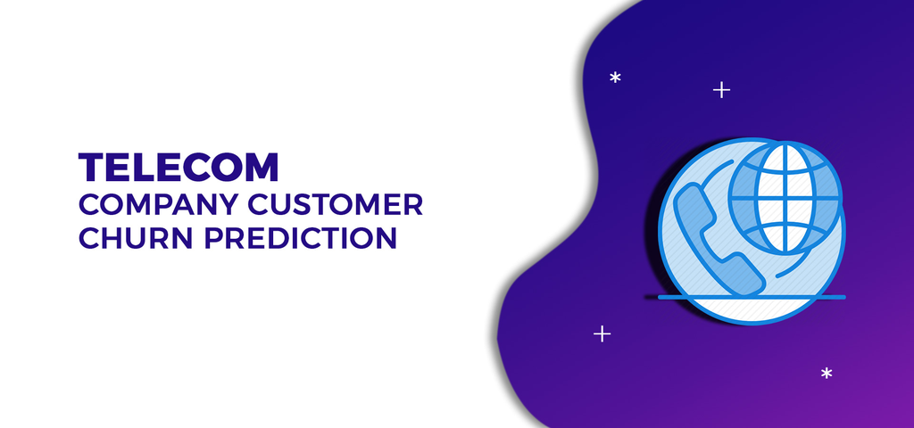

# Required solution

A supervised learning algorithm, such as logistic regression or decision trees, can be trained on the data to predict the likelihood of customer churn. The company can then use this model to identify at-risk customers and implement targeted retention strategies. Additionally, the company can use feature importance metrics to identify which factors are most strongly associated with customer churn and make changes to their business practices accordingly.

```python
input_data = np.array([
    ['Male', 0, 'No', 'No', 25, 'Yes', 'No', 'Fiber optic', 'Yes', 'No', 'Yes', 'Yes', 'Yes', 'Yes', 'Month-to-month', 'Yes', 'Electronic check', 106, 2787]
])

df = pd.DataFrame(input_data, columns=['gender', 'SeniorCitizen', 'Partner', 'Dependents', 'tenure',
       'PhoneService', 'MultipleLines', 'InternetService', 'OnlineSecurity',
       'OnlineBackup', 'DeviceProtection', 'TechSupport', 'StreamingTV',
       'StreamingMovies', 'Contract', 'PaperlessBilling', 'PaymentMethod',
       'MonthlyCharges', 'TotalCharges'])
df
```

|  | gender | SeniorCitizen | Partner | Dependents | tenure | PhoneService | MultipleLines | InternetService | OnlineSecurity | OnlineBackup | DeviceProtection | TechSupport | StreamingTV | StreamingMovies | Contract | PaperlessBilling | PaymentMethod | MonthlyCharges | TotalCharges |
| --- | --- | --- | --- | --- | --- | --- | --- | --- | --- | --- | --- | --- | --- | --- | --- | --- | --- | --- | --- |
| 0 | Male | 0 | No | No | 25 | Yes | No | Fiber optic | Yes | No | Yes | Yes | Yes | Yes | Month-to-month | Yes | Electronic check | 106 | 2787 |

Required solution is to predict the likelihood of customer churn for given input of first sample of test data: results are

## Positive probability: 0.71

## Negative probability: 0.29

According to the results this perticular customer has

# Churned

Additionally, the company wants feature importance metrics to identify which factors are most strongly associated with customer churn and make changes to their business practices accordingly.

# Strongly associated factors are:

## Important Features which is extracted from RandomForestClassifier feature*importances*

##### 5. PaymentMethod

Based on the analysis using the RandomForestClassifier and Logistic Regression models, it was found that certain factors are strongly associated with customer churn, including tenure, total charges, monthly charges, contract, payment method, online security, internet service, and tech support. These factors can be used by the company to focus on retaining their customers and reducing churn.

Using the Logistic Regression model, a sample customer was predicted to have a 70% probability of churning, indicating that they are likely to discontinue their services with the company. This underscores the importance of companies to use data-driven approaches to identify customers who are at risk of churning and take proactive measures to retain them.

Overall, by leveraging predictive analytics, companies can gain valuable insights into customer behavior and use these insights to inform their customer retention strategies, ultimately reducing churn and improving customer satisfaction.

# Thank you

##### Project by

Shreyanth H G

Batch 108B